# Stock Market Reaction to Major News Events

**A Data Analyst Portfolio Project**  
**Python | Pandas | NumPy | EDA | Data Transformation | Statistical Analysis | Power BI**

## Business Question

When major news affects a company, **how does its stock react, how long does the reaction last, and does the price recover afterwards?**

### What I wanted to understand

- How strongly does a stock react on the first trading day after major news?
- Does the reaction continue over the following 10 trading days?
- Do some types of news create stronger or longer-lasting reactions?
- Do large price drops or jumps tend to reverse?
- Are the observed reactions different from what could happen on ordinary trading days?
- Which companies and event categories show the strongest reactions?

## Project Scope

- **Companies:** 20 large companies
- **News period:** 2025
- **Financial news source:** FinDailyKG, built from GDELT
- **Market data:** Yahoo Finance
- **Benchmark:** SPY / S&P 500 ETF
- **Analysis window:** Day -1 to Day +10
- **Output:** Analysis tables and Power BI-ready CSV files

## Skills Demonstrated

**ETL-style Data Preparation → EDA → Data Cleaning → Data Transformation → Financial Analysis → Statistical Analysis → Data Visualization → Power BI**

> This project is an analytical ETL workflow rather than a dedicated data-engineering pipeline.  
> The focus is on preparing real-world data correctly before analysis.

## Analytical Workflow

### 1. Extract

- Read financial news data from Parquet files.
- Extract organisation/article relationships for the selected companies.
- Obtain historical stock prices for the companies and SPY.

### 2. Transform

- Clean and standardise headlines.
- Map company names to stock tickers.
- Remove duplicate company-article relationships.
- Identify relevant business events.
- Categorise events using business-event keywords.
- Remove irrelevant financial-news noise.
- Convert publication timestamps to New York time.
- Assign each headline to the trading day that could react to it.
- Calculate daily returns and abnormal returns.
- Create event-level reaction windows.

### 3. Load

- Create cleaned analytical tables.
- Export event-level, category-level and company-level results.
- Create long-format data suitable for Power BI.

### 4. Explore

- Examine event distributions.
- Compare companies and event categories.
- Analyse abnormal-return patterns.
- Study persistence and recovery.

### 5. Analyse

- Calculate abnormal returns and CAR.
- Compare reactions with random trading days.
- Run statistical tests.
- Interpret the results carefully without claiming causality.

```python
# Run once if a library is missing, then restart the kernel if needed.
%pip install pandas numpy pyarrow scipy matplotlib seaborn yfinance
```

```python
import re
import random
from datetime import timedelta
from pathlib import Path

import numpy as np
import pandas as pd
import matplotlib.pyplot as plt
import seaborn as sns

from scipy import stats
from IPython.display import display

pd.set_option("display.max_columns", 50)
pd.set_option("display.width", 150)

sns.set_theme(style="whitegrid")
```

```python
# File locations
DATA_FOLDER = Path(r"E:\downloads_Ranjeetha\Finance_project")

# Output folder for cleaned tables and charts
OUTPUT_FOLDER = Path("outputs")
OUTPUT_FOLDER.mkdir(exist_ok=True)

PRICE_FILE = Path("stock_prices.csv")

# Study settings
BENCHMARK = "SPY"
PRICE_START = "2024-12-01"
PRICE_END = "2026-02-01"

MARKET_CLOSE_HOUR = 16
SHOCK_SIZE = 0.01
PERSIST_RATIO = 0.5
```

# Data Understanding and Initial EDA

Before transforming the data, I first looked at how the source data was organised.

The FinDailyKG data contains three main tables:

| Table | Purpose |
| --- | --- |
| `articles` | News article headline, time, website and URL |
| `article_org_edges` | Links between articles and organisations |
| `org_universe` | Organisation names appearing in the dataset |

The organisation-to-article relationship table is large, so I later filter it to the 20 companies used in this study.

### EDA objective at this stage

I want to understand:

- how many organisations are present,
- which organisations have the most articles,
- how the source data is structured,
- and what information is available before beginning the cleaning process.

This initial inspection helps avoid making assumptions about the raw dataset.

```python
orgs = pd.read_parquet(
    DATA_FOLDER / "org_universe_2025.parquet"
)

print("Organisation names in the dataset:", len(orgs))

display(
    orgs.sort_values("n_articles", ascending=False).head(10)
)
```

```
Organisation names in the dataset: 293057
```

|  | org_norm | n_mentions | n_articles | min_date | max_date |
| --- | --- | --- | --- | --- | --- |
| 0 | united states | 119049 | 119049 | 2025-01-01 | 2025-12-31 |
| 1 | nasdaq | 78105 | 78105 | 2025-01-01 | 2025-12-31 |
| 2 | exchange commission | 39476 | 39476 | 2025-01-01 | 2025-12-31 |
| 3 | federal reserve | 35794 | 35794 | 2025-01-01 | 2025-12-31 |
| 4 | white house | 22850 | 22850 | 2025-01-01 | 2025-12-31 |
| 5 | securities exchange commission | 22801 | 22801 | 2025-01-01 | 2025-12-31 |
| 6 | nvidia | 20415 | 20415 | 2025-01-01 | 2025-12-31 |
| 7 | morgan stanley | 18772 | 18772 | 2025-01-01 | 2025-12-31 |
| 8 | barclays | 17967 | 17967 | 2025-01-01 | 2025-12-31 |
| 9 | jpmorgan chase co | 16162 | 16162 | 2025-01-01 | 2025-12-31 |

# Company Selection and Data Mapping

The same company can appear under different names in a news dataset.

For example, a company may appear as:

- company name
- company corporation
- company inc.
- abbreviated company name

I therefore create a simple mapping between:

**Dataset organisation name → Company → Stock ticker**

This is an important data-transformation step because the news data and stock-price data use different identifiers.

### Why this matters

Without consistent identifiers, the news events could not be matched reliably to the corresponding stock prices.

```python
# Company, ticker, dataset spellings, and headline terms
companies = [
    ("NVIDIA", "NVDA",
     ["nvidia", "nvidia corp", "nvidia corporation", "nvidia inc"],
     ["nvidia"]),

    ("Microsoft", "MSFT",
     ["microsoft", "microsoft corp", "microsoft corporation", "microsoft co"],
     ["microsoft"]),

    ("Alphabet", "GOOGL",
     ["google", "alphabet inc", "google inc"],
     ["alphabet", "google"]),

    ("Meta Platforms", "META",
     ["facebook", "meta platforms inc", "facebook inc"],
     ["meta", "facebook"]),

    ("Oracle", "ORCL",
     ["oracle", "oracle corporation", "oracle corp", "oracle co"],
     ["oracle"]),

    ("Intel", "INTC",
     ["intel", "intel corp", "intel corporation", "intel co"],
     ["intel"]),

    ("Broadcom", "AVGO",
     ["broadcom", "broadcom inc", "broadcom corporation", "broadcom corp"],
     ["broadcom"]),

    ("Tesla", "TSLA",
     ["tesla inc", "tesla motors", "tesla motors inc"],
     ["tesla"]),

    ("Netflix", "NFLX",
     ["netflix", "netflix inc"],
     ["netflix"]),

    ("Walmart", "WMT",
     ["walmart", "walmart inc"],
     ["walmart"]),

    ("Boeing", "BA",
     ["boeing"],
     ["boeing"]),

    ("JPMorgan Chase", "JPM",
     ["jpmorgan chase co", "jp morgan", "jp morgan chase",
      "jp morgan chase co"],
     ["jpmorgan", "jp morgan"]),

    ("Morgan Stanley", "MS",
     ["morgan stanley", "morgan stanley co"],
     ["morgan stanley"]),

    ("Goldman Sachs", "GS",
     ["goldman sachs group", "goldman sachs",
      "goldman sachs group inc", "goldman sachs co"],
     ["goldman sachs"]),

    ("Citigroup", "C",
     ["citigroup", "citigroup inc"],
     ["citigroup", "citi"]),

    ("Wells Fargo", "WFC",
     ["wells fargo company", "wells fargo", "wells fargo co"],
     ["wells fargo"]),

    ("Barclays", "BCS",
     ["barclays", "barclays plc"],
     ["barclays"]),

    ("Deutsche Bank", "DB",
     ["deutsche bank", "deutsche bank aktiengesellschaft"],
     ["deutsche bank"]),

    ("BlackRock", "BLK",
     ["blackrock", "blackrock inc"],
     ["blackrock"]),

    ("Berkshire Hathaway", "BRK-B",
     ["berkshire hathaway", "berkshire hathaway inc"],
     ["berkshire hathaway", "berkshire"]),
]

lookalikes = {
    "BlackRock": [
        "blackrock silver",
        "blackrock gold",
        "blackrock neurotech"
    ],
    "Oracle": [
        "oracle of omaha"
    ],
    "Meta Platforms": [
        "meta-analysis"
    ],
    "Tesla": [
        "nikola tesla"
    ],
    "Citigroup": [
        "citi trends",
        "citi bike",
        "citi field"
    ],
    "Berkshire Hathaway": [
        "berkshire hills",
        "berkshire grey"
    ],
}

org_to_company = {}
company_to_ticker = {}
headline_words = {}

for company, ticker, org_names, words in companies:
    company_to_ticker[company] = ticker
    headline_words[company] = words

    for name in org_names:
        org_to_company[name] = company

tickers = [c[1] for c in companies]

print(
    len(companies),
    "companies,",
    len(org_to_company),
    "dataset spellings"
)
```

```
20 companies, 57 dataset spellings
```

```python
# Check that the company spellings exist in the source data
known_names = set(orgs["org_norm"])

missing_names = [
    name for name in org_to_company
    if name not in known_names
]

print("Spellings not found in the dataset:", missing_names)

# Example EDA check for one company
display(
    orgs[
        orgs["org_norm"].str.contains(
            "nvidia",
            case=False,
            na=False
        )
    ].sort_values(
        "n_articles",
        ascending=False
    ).head(8)
)
```

```
Spellings not found in the dataset: []
```

|  | org_norm | n_mentions | n_articles | min_date | max_date |
| --- | --- | --- | --- | --- | --- |
| 6 | nvidia | 20415 | 20415 | 2025-01-01 | 2025-12-31 |
| 170 | nvidia corp | 1195 | 1195 | 2025-01-02 | 2025-12-31 |
| 1866 | nvidia corporation | 151 | 151 | 2025-01-06 | 2025-12-30 |
| 25656 | club name nvidia | 10 | 10 | 2025-01-28 | 2025-12-24 |
| 29842 | nvidia data center | 8 | 8 | 2025-02-19 | 2025-11-19 |
| 36876 | bloomberg nvidia corp | 6 | 6 | 2025-01-06 | 2025-10-29 |
| 39844 | chipmaker nvidia corp | 6 | 6 | 2025-03-05 | 2025-09-10 |
| 44537 | nvidia inc | 5 | 5 | 2025-01-07 | 2025-05-28 |

# ETL: Build the News Analysis Table

This is the main **data preparation stage** of the project.

### Extract

I extract only the article-company relationships relevant to my selected companies.

### Transform

I then:

- remove duplicate company-article relationships,
- attach article headlines and timestamps,
- map companies to stock tickers,
- convert GDELT timestamps into usable datetime values,
- remove incomplete records,
- create a lowercase headline field for text-based filtering.

The goal is to create one clean table that can be used for the event analysis.

> **ETL note:** This project uses ETL-style data extraction and transformation for analytical purposes. It is not presented as a production ETL pipeline.

```python
# Extract only the columns and companies needed for the analysis
edges = pd.read_parquet(
    DATA_FOLDER / "article_org_edges_2025.parquet",
    columns=["article_id", "org_norm", "tone_score"],
    filters=[
        ("org_norm", "in", list(org_to_company))
    ],
)

edges["company"] = edges["org_norm"].map(org_to_company)

print("Rows for my companies:", len(edges))

# Remove repeated company-article relationships
edges = edges.sort_values(
    "tone_score",
    na_position="last"
)

edges = edges.drop_duplicates(
    ["article_id", "company"]
)

print("After removing repeats:", len(edges))
```

```
Rows for my companies: 202736
After removing repeats: 195033
```

```python
articles = pd.read_parquet(
    DATA_FOLDER / "articles_2025.parquet",
    columns=[
        "article_id",
        "seendate",
        "title",
        "domain",
        "url"
    ],
)

articles = articles.drop_duplicates("article_id")

news = edges.merge(
    articles,
    on="article_id",
    how="inner"
)

news["ticker"] = news["company"].map(
    company_to_ticker
)

# Convert GDELT timestamp to UTC datetime
news["published_utc"] = pd.to_datetime(
    news["seendate"],
    format="%Y%m%dT%H%M%SZ",
    utc=True,
    errors="coerce"
)

news["headline"] = (
    news["title"]
    .fillna("")
    .str.strip()
)

news = news[
    (news["headline"] != "") &
    news["published_utc"].notna()
].copy()

news["headline_lc"] = news["headline"].str.lower()

log = [
    ("Company-article pairs", len(news))
]

print("Company-article pairs:", len(news))

display(
    news[
        ["company", "published_utc", "headline"]
    ].head()
)
```

```
Company-article pairs: 195023
```

|  | company | published_utc | headline |
| --- | --- | --- | --- |
| 0 | Oracle | 2025-12-13 02:15:00+00:00 | Global Markets Slide as Tech Stocks Sink , Yie... |
| 1 | Broadcom | 2025-12-13 02:15:00+00:00 | Global Markets Slide as Tech Stocks Sink , Yie... |
| 2 | NVIDIA | 2025-12-13 02:15:00+00:00 | Global Markets Slide as Tech Stocks Sink , Yie... |
| 3 | Meta Platforms | 2025-12-28 12:30:00+00:00 | Drivers hit with doubled traffic fines |
| 4 | Meta Platforms | 2025-12-19 11:00:00+00:00 | Delhi pollution : Knee - jerk governance , per... |

# EDA + Event Identification

At this point I have a news table, but not every news article should be treated as a market event.

### Exploratory question

**What type of information is actually present in the headlines?**

For this project I focus on headlines describing a meaningful company or business event, such as:

- earnings and guidance,
- acquisitions and major deals,
- leadership changes,
- legal or regulatory developments,
- products and business changes,
- macroeconomic or geopolitical developments.

I remove headlines that are mainly:

- analyst opinions,
- fund/share holdings,
- market commentary,
- earnings previews,
- general stock forecasts.

This step combines **EDA, text-based data cleaning and business-rule transformation**.

```python
def has_any(text, words):
    # Whole-word matching prevents accidental matches
    pattern = (
        r"\b(?:"
        + "|".join(re.escape(w) for w in words)
        + r")\b"
    )

    return text.str.contains(
        pattern,
        regex=True
    )


# The company must appear in the headline
named = pd.Series(
    False,
    index=news.index
)

for company, words in headline_words.items():
    rows = news["company"] == company

    named.loc[rows] = has_any(
        news.loc[rows, "headline_lc"],
        words
    )

news = news[named].copy()

log.append(
    ("Company named in headline", len(news))
)


# Remove company-name lookalikes
for company, phrases in lookalikes.items():

    bad = (
        (news["company"] == company)
        &
        news["headline_lc"].str.contains(
            "|".join(phrases),
            regex=True
        )
    )

    news = news[~bad]

log.append(
    ("Look-alikes removed", len(news))
)

print(log[-3:])
```

```
[('Company-article pairs', 195023), ('Company named in headline', 16543), ('Look-alikes removed', 16529)]
```

```python
category_words = {

    "Earnings / Guidance": [
        "earnings",
        "quarterly results",
        "financial results",
        "revenue",
        "profit",
        "loss",
        "eps",
        "guidance",
        "forecast",
        "outlook",
    ],

    "M&A / Major Deal": [
        "acquire",
        "acquires",
        "acquisition",
        "merger",
        "merges",
        "takeover",
        "deal",
        "agreement",
        "contract",
        "partnership",
    ],

    "Leadership": [
        "appoints",
        "appointed",
        "appoint",
        "resigns",
        "resignation",
        "steps down",
        "new ceo",
        "new cfo",
        "chief executive",
        "chief financial officer",
    ],

    "Legal / Regulatory": [
        "lawsuit",
        "sued",
        "investigation",
        "fine",
        "fined",
        "penalty",
        "regulator",
        "regulatory",
        "approval",
        "approved",
        "ban",
        "banned",
        "antitrust",
        "court",
    ],

    "Product / Business": [
        "launch",
        "launches",
        "launched",
        "layoffs",
        "job cuts",
        "restructuring",
        "expansion",
        "opens",
        "closure",
        "recall",
        "new product",
    ],

    "Macro / Geopolitical": [
        "tariff",
        "tariffs",
        "sanction",
        "sanctions",
        "trade war",
        "interest rate",
        "fed",
        "federal reserve",
        "inflation",
        "government policy",
    ],
}


news["event_category"] = "Other"

for category, words in category_words.items():

    matches = has_any(
        news["headline_lc"],
        words
    )

    news.loc[
        matches &
        (news["event_category"] == "Other"),
        "event_category"
    ] = category


candidates = news[
    news["event_category"] != "Other"
].copy()

candidates = candidates.drop_duplicates(
    [
        "company",
        "headline_lc",
        "published_utc"
    ]
)

log.append(
    (
        "Looks like an event + exact duplicates removed",
        len(candidates)
    )
)

candidates["event_category"].value_counts()
```

```
event_category
Earnings / Guidance     1734
M&A / Major Deal         639
Macro / Geopolitical     634
Legal / Regulatory       327
Product / Business       135
Leadership                69
Name: count, dtype: int64
```

```python
noise_words = {

    "Fund / share holdings": [
        "acquires shares of",
        "buys shares of",
        "sells shares of",
        "new stake in",
        "new position in",
        "stock position",
        "holdings in",
        "boosts stake",
        "raises stake",
        "lifts stake",
        "cuts stake",
        "trims stake",
        "lowers stake",
        "reduces stake",
        "increases stake",
        "etf",
        "etfs",
        "dividend",
        "portfolio",
        "hedge fund",
        "mutual fund",
        "institutional investors",
    ],

    "Analyst opinions": [
        "price target",
        "analyst rating",
        "analysts expect",
        "analysts see",
        "analyst says",
        "stock forecast",
        "stock prediction",
        "reiterates",
        "initiates coverage",
        "upgraded to",
        "downgraded to",
        "upgrades to",
        "downgrades to",
        "buy rating",
        "sell rating",
        "hold rating",
        "zacks",
        "technical analysis",
    ],

    "Previews": [
        "earnings preview",
        "what to expect",
        "what to watch",
        "ahead of earnings",
        "ahead of results",
        "outlook for",
        "forecast for",
        "gears up",
    ],

    "Market commentary": [
        "stock market",
        "stocks today",
        "stocks to watch",
        "dow jones",
        "futures",
        "market wrap",
        "market update",
        "market recap",
        "magnificent seven",
        "magnificent 7",
    ],
}


share_count_rule = (
    r"\b(?:acquires|acquired|buys|bought|sells|sold|"
    r"purchases|purchased)\s+\d[\d,\. ]*\s*shares"
)


def is_noise(text):

    result = text.str.contains(
        share_count_rule,
        regex=True
    )

    for words in noise_words.values():
        result = result | has_any(
            text,
            words
        )

    return result


before = len(candidates)

candidates = candidates[
    ~is_noise(
        candidates["headline_lc"]
    )
].copy()

log.append(
    ("Noise removed", len(candidates))
)

print(
    "Removed",
    before - len(candidates),
    "noise headlines."
)

print(
    "Left:",
    len(candidates)
)
```

```
Removed 702 noise headlines.
Left: 2836
```

```python
def noise(headline):
    return bool(
        is_noise(
            pd.Series([headline.lower()])
        ).iloc[0]
    )


assert noise(
    "Acme Capital Acquires 665 Shares of The Boeing Company"
)

assert noise(
    "Goldman Sachs raises Tesla price target to $400"
)

assert noise(
    "Stock Market Today: Dow Jones rises as Nvidia jumps"
)

assert not noise(
    "Netflix reports record quarterly earnings"
)

assert not noise(
    "Nvidia to buy Run:ai in $700 million deal, shares jump"
)

assert not noise(
    "Intel lowers FY25 outlook after weak revenue"
)

print("All filter tests passed")
```

```
All filter tests passed
```

```python
# A manual sample check is useful because keyword rules
# can never replace human review completely.

display(
    candidates[
        ["company", "event_category", "headline"]
    ].sample(
        15,
        random_state=42
    )
)
```

|  | company | event_category | headline |
| --- | --- | --- | --- |
| 26006 | Alphabet | Legal / Regulatory | Google wont be forced to sell Chrome after jud... |
| 99420 | Alphabet | Macro / Geopolitical | China counters with tariffs on US products . I... |
| 79859 | NVIDIA | Earnings / Guidance | NVIDIA ( NVDA ) Guidance Could Be Messy , Ban... |
| 149141 | Intel | Earnings / Guidance | Intel dumps planned European projects after fl... |
| 126288 | Alphabet | M&A / Major Deal | Alphabet $32 billion Wiz deal promises windfal... |
| 22476 | Goldman Sachs | Macro / Geopolitical | Goldman Sachs pares risk after tariff move , b... |
| 59377 | Walmart | Earnings / Guidance | Walmart shares fall over 5 % despite 8 % growt... |
| 99465 | Walmart | Macro / Geopolitical | Walmart sees a way to benefit from the tariff ... |
| 31887 | Meta Platforms | Legal / Regulatory | Meta faces historic antitrust trial that could... |
| 110699 | Meta Platforms | Earnings / Guidance | Meta first quarter earnings , revenue beat Wal... |
| 102222 | Netflix | Earnings / Guidance | Netflix Dips After Q3 Earnings Marred by Tax D... |
| 137140 | Walmart | Macro / Geopolitical | Here what tariffs could make more expensive at... |
| 174506 | Boeing | Macro / Geopolitical | Boeing , aerospace suppliers primed for disrup... |
| 20687 | NVIDIA | Legal / Regulatory | Nvidia shares dip premarket : Nvidia stock hit... |
| 40723 | Microsoft | M&A / Major Deal | OpenAI may move forward with new business stru... |

# Stock Price Data

I now bring in the second major data source: historical stock prices.

I use **adjusted closing prices** so that stock splits and dividends are reflected in the price series.

The 20 companies are compared with **SPY**, which is used as a broad market benchmark.

### EDA check

Before calculating reactions, I check:

- number of trading days,
- date range,
- missing prices,
- price-data availability.

This prevents incomplete market data from silently affecting the event analysis.

```python
if PRICE_FILE.exists():

    prices = pd.read_csv(
        PRICE_FILE,
        index_col=0,
        parse_dates=True
    )

    print(
        "Loaded saved prices from",
        PRICE_FILE
    )

else:

    import yfinance as yf

    raw = yf.download(
        tickers + [BENCHMARK],
        start=PRICE_START,
        end=PRICE_END,
        auto_adjust=True,
        progress=False
    )

    prices = raw["Close"]

    prices.index = pd.to_datetime(
        prices.index
    ).tz_localize(None)

    prices.to_csv(
        PRICE_FILE
    )

    print(
        "Downloaded prices and saved to",
        PRICE_FILE
    )


prices = prices.dropna(
    subset=[BENCHMARK]
).sort_index()

print(
    "Trading days:",
    len(prices),
    "| from",
    prices.index.min().date(),
    "to",
    prices.index.max().date()
)

print(
    "Missing prices per ticker:",
    prices.isna().sum()[
        prices.isna().sum() > 0
    ].to_dict()
)

display(prices.tail(3))
```

```
Loaded saved prices from stock_prices.csv
Trading days: 291 | from 2024-12-02 to 2026-01-30
Missing prices per ticker: {}
```

| Date | AVGO | BA | BCS | BLK | BRK-B | C | DB | GOOGL | GS | INTC | JPM | META | MS | MSFT | NFLX | NVDA | ORCL | SPY | TSLA | WFC | WMT |
| --- | --- | --- | --- | --- | --- | --- | --- | --- | --- | --- | --- | --- | --- | --- | --- | --- | --- | --- | --- | --- | --- |
| 2026-01-28 | 331.413452 | 241.589996 | 25.944016 | 1103.546387 | 473.489990 | 112.500961 | 38.148758 | 335.357666 | 923.294556 | 48.779999 | 297.896545 | 667.012817 | 179.383545 | 478.593689 | 84.639999 | 191.072891 | 171.601593 | 690.030396 | 431.459991 | 86.604279 | 115.832367 |
| 2026-01-29 | 328.917236 | 234.039993 | 26.266483 | 1109.557617 | 476.790009 | 113.486099 | 37.743534 | 337.593262 | 926.556885 | 48.660000 | 303.492615 | 736.414185 | 179.442581 | 430.767151 | 83.160004 | 192.060562 | 167.837875 | 688.661072 | 416.559998 | 89.172012 | 116.667053 |
| 2026-01-30 | 329.484100 | 233.720001 | 26.139452 | 1100.860474 | 480.529999 | 113.988503 | 37.840015 | 337.343781 | 921.914795 | 46.470001 | 302.967682 | 714.660217 | 180.827469 | 427.577362 | 83.489998 | 190.683792 | 163.438583 | 686.607117 | 430.410004 | 89.024437 | 118.386108 |

```python
# Daily stock returns
returns = prices.pct_change()

# Abnormal return:
# company return minus SPY return on the same day
abnormal = returns[tickers].sub(
    returns[BENCHMARK],
    axis=0
)

display(
    abnormal.describe().T[
        [
            "count",
            "mean",
            "std",
            "min",
            "max"
        ]
    ]
)
```

|  | count | mean | std | min | max |
| --- | --- | --- | --- | --- | --- |
| NVDA | 290.0 | 0.000963 | 0.022780 | -0.155536 | 0.082208 |
| MSFT | 290.0 | -0.000441 | 0.012465 | -0.097947 | 0.069167 |
| GOOGL | 290.0 | 0.001968 | 0.015834 | -0.076978 | 0.085946 |
| META | 290.0 | 0.000361 | 0.018325 | -0.102350 | 0.116278 |
| ORCL | 290.0 | -0.000232 | 0.033524 | -0.123763 | 0.356597 |
| INTC | 290.0 | 0.002561 | 0.038584 | -0.170650 | 0.223038 |
| AVGO | 290.0 | 0.002467 | 0.030715 | -0.159823 | 0.244525 |
| TSLA | 290.0 | 0.000816 | 0.032504 | -0.137766 | 0.121881 |
| NFLX | 290.0 | -0.000630 | 0.018354 | -0.095482 | 0.091322 |
| WMT | 290.0 | 0.000433 | 0.014799 | -0.061128 | 0.079848 |
| BA | 290.0 | 0.001052 | 0.018594 | -0.055430 | 0.099617 |
| JPM | 290.0 | 0.000365 | 0.010599 | -0.045772 | 0.026995 |
| MS | 290.0 | 0.000854 | 0.011714 | -0.045798 | 0.055082 |
| GS | 290.0 | 0.001188 | 0.012033 | -0.042834 | 0.043585 |
| C | 290.0 | 0.001361 | 0.013217 | -0.072096 | 0.046708 |
| WFC | 290.0 | 0.000280 | 0.013442 | -0.050503 | 0.072686 |
| BCS | 290.0 | 0.002090 | 0.014779 | -0.065788 | 0.059323 |
| DB | 290.0 | 0.002616 | 0.018114 | -0.050622 | 0.126937 |
| BLK | 290.0 | -0.000035 | 0.011579 | -0.054478 | 0.056626 |
| BRK-B | 290.0 | -0.000504 | 0.011676 | -0.046620 | 0.045658 |

# Assigning the Reaction Day

News timestamps need to be connected to actual trading days.

I convert the publication time to New York time and use the following rule:

| News timing | Day 0 |
| --- | --- |
| Trading day before 4 PM | Same trading day |
| Trading day at/after 4 PM | Next trading day |
| Weekend or market holiday | Next trading day |

**Day 0** therefore represents the first trading day on which the market could reasonably react to the headline.

This transformation is important because a calendar date and a stock-market trading date are not always the same.

```python
trading_dates = set(
    prices.index.date
)


def find_reaction_day(
    published_utc,
    trading_dates
):

    ny_time = published_utc.tz_convert(
        "America/New_York"
    )

    day = ny_time.date()

    if ny_time.hour >= MARKET_CLOSE_HOUR:
        day = day + timedelta(days=1)

    while day not in trading_dates:
        day = day + timedelta(days=1)

    if day > max(trading_dates):
        return pd.NaT

    return day


# Small checks for the trading-day logic
test_days = {
    pd.Timestamp(d).date()
    for d in [
        "2025-01-02",
        "2025-01-03",
        "2025-01-06"
    ]
}


def check(utc_text, expected):

    result = find_reaction_day(
        pd.Timestamp(
            utc_text,
            tz="UTC"
        ),
        test_days
    )

    assert str(result) == expected


check(
    "2025-01-02 14:00",
    "2025-01-02"
)

check(
    "2025-01-03 20:59",
    "2025-01-03"
)

check(
    "2025-01-03 21:00",
    "2025-01-06"
)

check(
    "2025-01-04 15:00",
    "2025-01-06"
)

check(
    "2025-01-01 15:00",
    "2025-01-02"
)

print("Trading-day tests passed")
```

```
Trading-day tests passed
```

```python
candidates["published_et"] = (
    candidates["published_utc"]
    .dt.tz_convert("America/New_York")
)

candidates["reaction_date"] = (
    candidates["published_utc"]
    .apply(
        lambda t: find_reaction_day(
            t,
            trading_dates
        )
    )
)

candidates["reaction_date"] = pd.to_datetime(
    candidates["reaction_date"]
)

candidates = candidates[
    (candidates["published_et"].dt.year == 2025)
    &
    candidates["reaction_date"].notna()
]

log.append(
    (
        "Published in 2025 with a reaction day",
        len(candidates)
    )
)

display(
    candidates[
        [
            "company",
            "published_et",
            "reaction_date",
            "headline"
        ]
    ].head()
)
```

|  | company | published_et | reaction_date | headline |
| --- | --- | --- | --- | --- |
| 99 | Meta Platforms | 2025-12-28 16:00:00-05:00 | 2025-12-29 | Meta Leaders Settle Shareholder Lawsuit Over F... |
| 114 | Meta Platforms | 2025-12-31 00:30:00-05:00 | 2025-12-31 | Meta sued by US Virgin Islands over ads for sc... |
| 174 | Tesla | 2025-12-24 01:15:00-05:00 | 2025-12-24 | Elon Musk Makes That Back In Nine Minutes : La... |
| 459 | Citigroup | 2025-12-31 07:00:00-05:00 | 2025-12-31 | Citi Moves Toward Russia Exit Despite $1 . 2 B... |
| 501 | Oracle | 2025-12-19 01:45:00-05:00 | 2025-12-19 | Baystreet . ca - Micron Hiked Guidance , Oracl... |

# Event Deduplication

The same real-world event can appear in many different news articles.

If every article were treated as a separate event, one stock movement could be counted multiple times.

Therefore, I keep one event for each:

**Company + Reaction Day + Event Category**

I retain the earliest article and record how many articles were associated with that event.

This is another important **data-cleaning and transformation step** before analysis.

```python
candidates = candidates.sort_values(
    [
        "ticker",
        "reaction_date",
        "event_category",
        "published_utc"
    ]
)

candidates["articles_behind_event"] = (
    candidates
    .groupby(
        [
            "ticker",
            "reaction_date",
            "event_category"
        ]
    )["article_id"]
    .transform("count")
)

events = candidates.drop_duplicates(
    [
        "ticker",
        "reaction_date",
        "event_category"
    ]
).copy()

events = events.sort_values(
    [
        "reaction_date",
        "ticker"
    ]
).reset_index(drop=True)

events["event_id"] = (
    events.index + 1
)

log.append(
    ("FINAL EVENTS", len(events))
)

events = events[
    [
        "event_id",
        "company",
        "ticker",
        "event_category",
        "headline",
        "published_et",
        "reaction_date",
        "articles_behind_event",
        "domain",
        "url",
        "tone_score"
    ]
]

print(
    pd.DataFrame(
        log,
        columns=[
            "step",
            "rows left"
        ]
    ).to_string(index=False)
)

print(
    "\nFinal events:",
    len(events),
    "| companies:",
    events["company"].nunique()
)
```

```
                                          step  rows left
                         Company-article pairs     195023
                     Company named in headline      16543
                           Look-alikes removed      16529
Looks like an event + exact duplicates removed       3538
                                 Noise removed       2836
         Published in 2025 with a reaction day       2836
                                  FINAL EVENTS       1109

Final events: 1109 | companies: 20
```

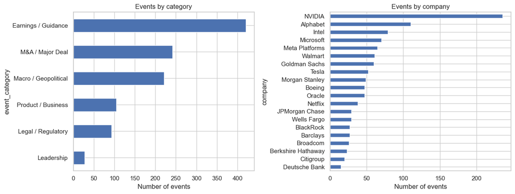

```python
# EDA: distribution of identified events

fig, axes = plt.subplots(
    1,
    2,
    figsize=(13, 5)
)

events[
    "event_category"
].value_counts().sort_values().plot.barh(
    ax=axes[0]
)

axes[0].set_title(
    "Events by category"
)

axes[0].set_xlabel(
    "Number of events"
)


events[
    "company"
].value_counts().sort_values().plot.barh(
    ax=axes[1]
)

axes[1].set_title(
    "Events by company"
)

axes[1].set_xlabel(
    "Number of events"
)

plt.tight_layout()

plt.savefig(
    OUTPUT_FOLDER /
    "events_by_category_and_company.png",
    dpi=150
)

plt.show()
```

# Event-Based Financial Analysis

Now that the news data has been cleaned and the events have been identified, I measure the stock-market reaction.

For every event I collect abnormal returns from:

**Day -1 → Day 0 → Day +1 → ... → Day +10**

### Key measures

**Abnormal Return (AR)**  
Company return − SPY return

**Day 0**  
The first trading day on which the market could react to the news.

**Cumulative Abnormal Return (CAR)**  
The cumulative abnormal return over a period.

For example:

`CAR 0-3 = AR Day 0 + AR Day 1 + AR Day 2 + AR Day 3`

Day -1 is retained as a pre-event check to see whether some of the movement may have happened before the identified news reaction day.

```python
rows = []

for _, event in events.iterrows():

    position = prices.index.get_loc(
        event["reaction_date"]
    )

    window = abnormal[
        event["ticker"]
    ].iloc[
        position - 1:
        position + 11
    ].tolist()

    window = (
        window +
        [np.nan] * (12 - len(window))
    )

    rows.append(window)


ar_columns = (
    ["AR_before"] +
    [
        f"AR_day{d}"
        for d in range(0, 11)
    ]
)

events = events.join(
    pd.DataFrame(
        rows,
        columns=ar_columns
    )
)


for k in [1, 3, 5, 10]:

    columns = [
        f"AR_day{d}"
        for d in range(0, k + 1)
    ]

    events[
        f"CAR_0_{k}"
    ] = events[
        columns
    ].sum(
        axis=1,
        skipna=False
    )


complete = events[
    ar_columns[1:]
].notna().all(axis=1)

print(
    "Events with a complete Day 0 to Day 10 window:",
    complete.sum(),
    "of",
    len(events)
)
```

```
Events with a complete Day 0 to Day 10 window: 1109 of 1109
```

```python
# Validate one event calculation against the raw price data

sample = events[
    complete
].iloc[
    len(events[complete]) // 2
]

p = prices.index.get_loc(
    sample["reaction_date"]
)

stock_return = (
    prices[
        sample["ticker"]
    ].iloc[p]
    /
    prices[
        sample["ticker"]
    ].iloc[p - 1]
    - 1
)

market_return = (
    prices[BENCHMARK].iloc[p]
    /
    prices[BENCHMARK].iloc[p - 1]
    - 1
)

assert abs(
    (stock_return - market_return)
    -
    sample["AR_day0"]
) < 1e-12


assert abs(
    sample[
        [
            f"AR_day{d}"
            for d in range(0, 11)
        ]
    ].sum()
    -
    sample["CAR_0_10"]
) < 1e-12

print(
    "Manual check passed for",
    sample["company"],
    "on",
    sample["reaction_date"].date()
)
```

```
Manual check passed for Morgan Stanley on 2025-07-18
```

```python
summary_columns = {
    "Day 0": "AR_day0",
    "Day 1": "AR_day1",
    "Day 3": "AR_day3",
    "Day 5": "AR_day5",
    "Day 10": "AR_day10",
    "CAR 0-1": "CAR_0_1",
    "CAR 0-3": "CAR_0_3",
    "CAR 0-5": "CAR_0_5",
    "CAR 0-10": "CAR_0_10"
}


overview = pd.DataFrame({
    name: {
        "events": events[col].notna().sum(),
        "average %": events[col].mean() * 100,
        "median %": events[col].median() * 100,
        "% of events positive":
            (events[col].dropna() > 0).mean() * 100,
    }
    for name, col in summary_columns.items()
}).T

overview.round(3)
```

|  | events | average % | median % | % of events positive |
| --- | --- | --- | --- | --- |
| Day 0 | 1109.0 | 0.163 | 0.008 | 50.496 |
| Day 1 | 1109.0 | -0.014 | -0.055 | 49.234 |
| Day 3 | 1109.0 | 0.196 | 0.101 | 52.209 |
| Day 5 | 1109.0 | 0.036 | 0.034 | 51.217 |
| Day 10 | 1109.0 | 0.126 | 0.093 | 52.931 |
| CAR 0-1 | 1109.0 | 0.149 | 0.088 | 52.209 |
| CAR 0-3 | 1109.0 | 0.334 | 0.246 | 53.111 |
| CAR 0-5 | 1109.0 | 0.415 | 0.376 | 54.013 |
| CAR 0-10 | 1109.0 | 1.012 | 0.772 | 56.537 |

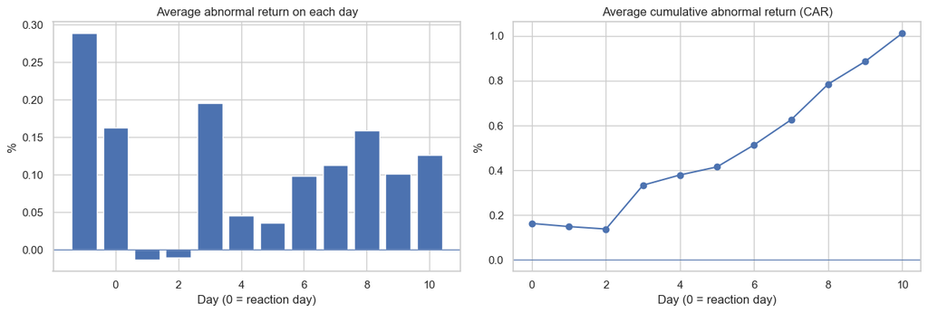

```python
# EDA: overall reaction pattern

days = list(range(-1, 11))

daily_average = [
    events[c].mean()
    for c in ar_columns
]

car_paths = (
    events.loc[
        complete,
        [
            f"AR_day{d}"
            for d in range(0, 11)
        ]
    ]
    .cumsum(axis=1)
)

fig, axes = plt.subplots(
    1,
    2,
    figsize=(13, 4.5)
)

axes[0].bar(
    days,
    [v * 100 for v in daily_average]
)

axes[0].axhline(
    0,
    linewidth=0.8
)

axes[0].set_title(
    "Average abnormal return on each day"
)

axes[0].set_xlabel(
    "Day (0 = reaction day)"
)

axes[0].set_ylabel("%")


axes[1].plot(
    range(0, 11),
    car_paths.mean() * 100,
    marker="o"
)

axes[1].axhline(
    0,
    linewidth=0.8
)

axes[1].set_title(
    "Average cumulative abnormal return (CAR)"
)

axes[1].set_xlabel(
    "Day (0 = reaction day)"
)

axes[1].set_ylabel("%")

plt.tight_layout()

plt.savefig(
    OUTPUT_FOLDER /
    "average_reaction.png",
    dpi=150
)

plt.show()
```

# Persistence Analysis

A strong Day 0 reaction does not necessarily mean the effect lasted.

I therefore compare the cumulative reaction through Day 10 with the original Day 0 reaction.

### Persistence ratio

`Persistence ratio = CAR 0-10 / AR Day 0`

Interpretation:

- **1.0** → the Day 0 move was broadly maintained
- **0.5** → at least half of the initial move remained
- **below 0** → the reaction moved past the original starting point in the opposite direction

I classify a reaction as **Persisted** when at least 50% of the Day 0 move remains in the same direction by Day 10.

```python
events["ratio_day10"] = (
    events["CAR_0_10"]
    /
    events["AR_day0"]
)

events["ratio_day10"] = (
    events["ratio_day10"]
    .replace(
        [np.inf, -np.inf],
        np.nan
    )
)

events["persisted"] = (
    events["ratio_day10"]
    >= PERSIST_RATIO
).astype(float)

events.loc[
    events["ratio_day10"].isna(),
    "persisted"
] = np.nan

events["persistence_status"] = np.where(
    events["ratio_day10"] >= PERSIST_RATIO,
    "Persisted",
    np.where(
        events["ratio_day10"] < 0,
        "Reversed",
        "Faded"
    )
)

events.loc[
    events["ratio_day10"].isna(),
    "persistence_status"
] = None

print(
    "Persisted in",
    round(
        events["persisted"].mean() * 100,
        1
    ),
    "% of events"
)

events[
    "persistence_status"
].value_counts()
```

```
Persisted in 54.5 % of events
```

```
persistence_status
Persisted    604
Reversed     445
Faded         60
Name: count, dtype: int64
```

# Recovery and Give-Back Analysis

I next focus on larger initial reactions.

A move of **1% or more in abnormal return on Day 0** is treated as a large first move.

For these events I calculate how much of the original move had reversed by Day 5 and Day 10.

### Interpretation

For a large **drop**:

**% reversed = recovery**

For a large **jump**:

**% reversed = give-back**

A value of 100% means the original move had fully reversed.

A negative value means the move became larger rather than reversing.

```python
# Recovery and continuation after large Day 0 moves
# Positive % = the original move reversed
# Negative % = the original move continued

is_big_drop = (
    events["AR_day0"] <= -SHOCK_SIZE
)

is_big_jump = (
    events["AR_day0"] >= SHOCK_SIZE
)

events["shock_type"] = None

events.loc[
    is_big_drop,
    "shock_type"
] = "Big drop"

events.loc[
    is_big_jump,
    "shock_type"
] = "Big jump"


# Percentage of the original Day 0 move that reversed
events["reversed_pct_day5"] = np.nan
events["reversed_pct_day10"] = np.nan

shock = events["shock_type"].notna()

events.loc[
    shock,
    "reversed_pct_day5"
] = (
    1
    - events.loc[shock, "CAR_0_5"]
    / events.loc[shock, "AR_day0"]
) * 100

events.loc[
    shock,
    "reversed_pct_day10"
] = (
    1
    - events.loc[shock, "CAR_0_10"]
    / events.loc[shock, "AR_day0"]
) * 100


# Recovery / continuation summary
recovery_table = (
    events[shock]
    .groupby("shock_type")
    .agg(
        events=("event_id", "count"),

        median_reversed_pct_day5=(
            "reversed_pct_day5",
            "median"
        ),

        median_reversed_pct_day10=(
            "reversed_pct_day10",
            "median"
        )
    )
)

recovery_table[
    "fully_reversed_by_day10_pct"
] = (
    events[shock]
    .groupby("shock_type")[
        "reversed_pct_day10"
    ]
    .apply(
        lambda s: (s >= 100).mean() * 100
    )
)

display(
    recovery_table.round(1)
)
```

| shock_type | events | median_reversed_pct_day5 | median_reversed_pct_day10 | fully_reversed_by_day10_pct |
| --- | --- | --- | --- | --- |
| Big drop | 274 | -8.2 | 48.0 | 41.2 |
| Big jump | 311 | 0.8 | -8.5 | 32.2 |

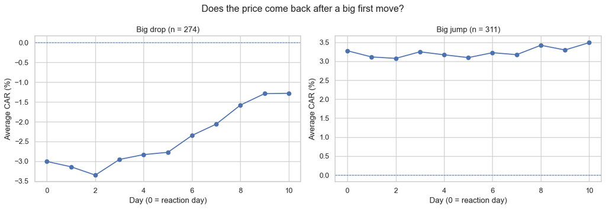

```python
# Recovery-path visualisation

fig, axes = plt.subplots(
    1,
    2,
    figsize=(13, 4.5)
)

day0_to_10 = [
    f"AR_day{d}"
    for d in range(0, 11)
]

for ax, shock_type in zip(
    axes,
    ["Big drop", "Big jump"]
):

    paths = (
        events.loc[
            (events["shock_type"] == shock_type)
            &
            complete,
            day0_to_10
        ]
        .cumsum(axis=1)
    )

    ax.plot(
        range(0, 11),
        paths.mean() * 100,
        marker="o"
    )

    ax.axhline(
        0,
        linestyle="--",
        linewidth=0.8
    )

    ax.set_title(
        f"{shock_type} (n = {len(paths)})"
    )

    ax.set_xlabel(
        "Day (0 = reaction day)"
    )

    ax.set_ylabel(
        "Average CAR (%)"
    )

plt.suptitle(
    "Does the price come back after a big first move?"
)

plt.tight_layout()

plt.savefig(
    OUTPUT_FOLDER /
    "recovery_paths.png",
    dpi=150
)

plt.show()
```

# Benchmarking Against Random Trading Days

Persistence can be misleading.

Even on ordinary trading days, stock prices move up and down and some moves will naturally continue for several days.

To provide a simple benchmark, I randomly select **20 trading-day windows for each event's stock** and calculate the same persistence measure.

I also compare news events with random days having similar first-move sizes.

This gives a more useful context than looking at event persistence alone.

```python
random.seed(42)

abnormal_arrays = {
    t: abnormal[t].to_numpy()
    for t in tickers
}

last_start = len(prices) - 11

random_rows = []

for _, event in events.iterrows():

    for _ in range(20):

        start = random.randint(
            1,
            last_start
        )

        window = abnormal_arrays[
            event["ticker"]
        ][
            start:
            start + 11
        ]

        if np.isnan(window).any():
            continue

        random_rows.append({
            "AR_day0": window[0],
            "CAR_0_10": window.sum()
        })


random_days = pd.DataFrame(
    random_rows
)

random_days["ratio_day10"] = (
    random_days["CAR_0_10"]
    /
    random_days["AR_day0"]
)

random_days["persisted"] = (
    random_days["ratio_day10"]
    >= PERSIST_RATIO
).astype(float)


bands = [
    0,
    0.01,
    0.02,
    1
]

band_names = [
    "under 1%",
    "1% to 2%",
    "over 2%"
]

events["move_size"] = pd.cut(
    events["AR_day0"].abs(),
    bands,
    labels=band_names,
    right=False
)

random_days["move_size"] = pd.cut(
    random_days["AR_day0"].abs(),
    bands,
    labels=band_names,
    right=False
)


check_table = pd.DataFrame({

    "news events: % persisted":
        events.groupby(
            "move_size",
            observed=True
        )["persisted"].mean() * 100,

    "random days: % persisted":
        random_days.groupby(
            "move_size",
            observed=True
        )["persisted"].mean() * 100,

    "number of events":
        events.groupby(
            "move_size",
            observed=True
        )["event_id"].count()
})

check_table[
    "difference (points)"
] = (
    check_table.iloc[:, 0]
    -
    check_table.iloc[:, 1]
)

check_table.round(1)
```

| move_size | news events: % persisted | random days: % persisted | number of events | difference (points) |
| --- | --- | --- | --- | --- |
| under 1% | 53.8 | 52.9 | 524 | 0.9 |
| 1% to 2% | 53.1 | 59.1 | 262 | -6.1 |
| over 2% | 56.7 | 56.4 | 323 | 0.2 |

# Statistical Analysis

After exploring the patterns visually, I use statistical tests to check whether the average reaction is different from zero.

A **one-sample t-test** compares the average abnormal return with zero.

I report:

- sample size,
- average reaction,
- t-statistic,
- p-value,
- Bonferroni-adjusted p-value.

Because multiple tests are performed, the Bonferroni adjustment provides a more conservative interpretation.

I also repeat the analysis after keeping only one event per company per trading day because several events may share the same stock return.

```python
def run_tests(data):

    rows = []

    for name, col in summary_columns.items():

        values = data[col].dropna()

        t_stat, p_value = (
            stats.ttest_1samp(
                values,
                0
            )
        )

        rows.append({
            "measure": name,
            "events": len(values),
            "average %":
                values.mean() * 100,
            "t-statistic": t_stat,
            "p-value": p_value
        })

    result = pd.DataFrame(rows)

    result[
        "p-value (Bonferroni)"
    ] = (
        result["p-value"]
        * len(result)
    ).clip(upper=1)

    result[
        "significant at 5%?"
    ] = np.where(
        result[
            "p-value (Bonferroni)"
        ] < 0.05,
        "Yes",
        "No"
    )

    return result


tests_all = run_tests(
    events
)

one_per_day = events.drop_duplicates(
    [
        "ticker",
        "reaction_date"
    ]
)

tests_one_per_day = run_tests(
    one_per_day
)

print(
    "ALL EVENTS (",
    len(events),
    ")"
)

display(
    tests_all.round(4)
)

print(
    "ONE EVENT PER COMPANY PER DAY (",
    len(one_per_day),
    ")"
)

display(
    tests_one_per_day.round(4)
)
```

```
ALL EVENTS ( 1109 )
```

|  | measure | events | average % | t-statistic | p-value | p-value (Bonferroni) | significant at 5%? |
| --- | --- | --- | --- | --- | --- | --- | --- |
| 0 | Day 0 | 1109 | 0.1630 | 1.6349 | 0.1024 | 0.9212 | No |
| 1 | Day 1 | 1109 | -0.0139 | -0.1895 | 0.8497 | 1.0000 | No |
| 2 | Day 3 | 1109 | 0.1957 | 2.6101 | 0.0092 | 0.0826 | No |
| 3 | Day 5 | 1109 | 0.0361 | 0.5889 | 0.5560 | 1.0000 | No |
| 4 | Day 10 | 1109 | 0.1256 | 2.1363 | 0.0329 | 0.2958 | No |
| 5 | CAR 0-1 | 1109 | 0.1490 | 1.2572 | 0.2089 | 1.0000 | No |
| 6 | CAR 0-3 | 1109 | 0.3337 | 2.1287 | 0.0335 | 0.3015 | No |
| 7 | CAR 0-5 | 1109 | 0.4154 | 2.3552 | 0.0187 | 0.1682 | No |
| 8 | CAR 0-10 | 1109 | 1.0116 | 4.7736 | 0.0000 | 0.0000 | Yes |

```
ONE EVENT PER COMPANY PER DAY ( 921 )
```

|  | measure | events | average % | t-statistic | p-value | p-value (Bonferroni) | significant at 5%? |
| --- | --- | --- | --- | --- | --- | --- | --- |
| 0 | Day 0 | 921 | 0.1962 | 2.0409 | 0.0415 | 0.3739 | No |
| 1 | Day 1 | 921 | 0.0047 | 0.0569 | 0.9547 | 1.0000 | No |
| 2 | Day 3 | 921 | 0.1687 | 2.0657 | 0.0391 | 0.3522 | No |
| 3 | Day 5 | 921 | 0.0300 | 0.4403 | 0.6599 | 1.0000 | No |
| 4 | Day 10 | 921 | 0.1532 | 2.4373 | 0.0150 | 0.1349 | No |
| 5 | CAR 0-1 | 921 | 0.2008 | 1.6371 | 0.1019 | 0.9175 | No |
| 6 | CAR 0-3 | 921 | 0.3955 | 2.3810 | 0.0175 | 0.1572 | No |
| 7 | CAR 0-5 | 921 | 0.4935 | 2.6436 | 0.0083 | 0.0751 | No |
| 8 | CAR 0-10 | 921 | 1.1166 | 4.8539 | 0.0000 | 0.0000 | Yes |

```python
# Pre-event check:
# Did the stock already move before the identified news day?

before = events[
    "AR_before"
].dropna()

t_stat, p_value = stats.ttest_1samp(
    before,
    0
)

average_before = (
    before.mean() * 100
)

print(
    f"Average abnormal return on Day -1: "
    f"{average_before:+.3f}% "
    f"(p-value = {p_value:.3f})"
)

if p_value < 0.05:
    print(
        "Finding: Day -1 is statistically different from zero."
    )

    print(
        "Interpretation: part of the observed reaction "
        "may have occurred before the headline was detected."
    )
else:
    print(
        "Finding: Day -1 is not statistically different from zero."
    )
```

```
Average abnormal return on Day -1: +0.289% (p-value = 0.004)
Finding: Day -1 is statistically different from zero.
Interpretation: part of the observed reaction may have occurred before the headline was detected.
```

# EDA by Event Category

The next stage of the EDA asks:

> **Do different types of business news produce different stock-market reactions?**

I compare:

- Day 0 abnormal return,
- Day 10 abnormal return,
- CAR 0-10,
- percentage of positive Day 0 reactions,
- persistence,
- reversal behaviour.

This helps move the analysis from an overall market reaction to **business-event-level insights**.

```python
events["positive_day0"] = (
    events["AR_day0"] > 0
).astype(float)

events.loc[
    events["AR_day0"].isna(),
    "positive_day0"
] = np.nan


def summarise(group_column):

    table = (
        events
        .groupby(group_column)
        .agg(
            events=("event_id", "count"),

            avg_day0_pct=(
                "AR_day0",
                "mean"
            ),

            avg_day10_pct=(
                "AR_day10",
                "mean"
            ),

            avg_CAR_0_10_pct=(
                "CAR_0_10",
                "mean"
            ),

            positive_day0_pct=(
                "positive_day0",
                "mean"
            ),

            persisted_pct=(
                "persisted",
                "mean"
            ),

            median_reversed_pct_day10=(
                "reversed_pct_day10",
                "median"
            ),
        )
    )

    for col in [
        "avg_day0_pct",
        "avg_day10_pct",
        "avg_CAR_0_10_pct",
        "positive_day0_pct",
        "persisted_pct"
    ]:

        table[col] = (
            table[col] * 100
        )

    return table.sort_values(
        "events",
        ascending=False
    )


category_summary = summarise(
    "event_category"
)

category_summary.round(2)
```

| event_category | events | avg_day0_pct | avg_day10_pct | avg_CAR_0_10_pct | positive_day0_pct | persisted_pct | median_reversed_pct_day10 |
| --- | --- | --- | --- | --- | --- | --- | --- |
| Earnings / Guidance | 420 | 0.13 | 0.17 | 1.29 | 51.43 | 55.95 | 18.65 |
| M&A / Major Deal | 242 | 0.34 | -0.16 | -0.08 | 49.17 | 52.89 | 46.57 |
| Macro / Geopolitical | 221 | 0.11 | 0.23 | 1.59 | 50.68 | 52.04 | 18.71 |
| Product / Business | 105 | -0.20 | 0.02 | 0.33 | 45.71 | 60.95 | 21.33 |
| Legal / Regulatory | 93 | 0.28 | 0.52 | 2.38 | 55.91 | 50.54 | 46.39 |
| Leadership | 28 | 0.48 | 0.23 | -0.32 | 46.43 | 53.57 | 18.46 |

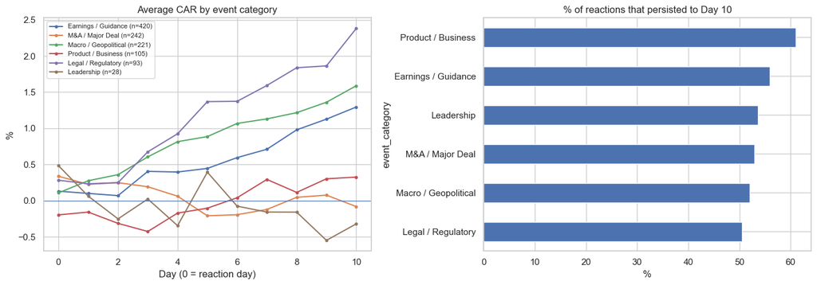

```python
fig, axes = plt.subplots(
    1,
    2,
    figsize=(14, 5)
)

# Average CAR path by category
for category in category_summary.index:

    rows = (
        events["event_category"]
        == category
    ) & complete

    path = (
        events.loc[
            rows,
            day0_to_10
        ]
        .cumsum(axis=1)
        .mean()
        * 100
    )

    axes[0].plot(
        range(0, 11),
        path,
        marker="o",
        markersize=3,
        label=f"{category} (n={rows.sum()})"
    )


axes[0].axhline(
    0,
    linewidth=0.8
)

axes[0].set_title(
    "Average CAR by event category"
)

axes[0].set_xlabel(
    "Day (0 = reaction day)"
)

axes[0].set_ylabel("%")

axes[0].legend(
    fontsize=8
)


category_summary[
    "persisted_pct"
].sort_values().plot.barh(
    ax=axes[1]
)

axes[1].set_title(
    "% of reactions that persisted to Day 10"
)

axes[1].set_xlabel("%")

plt.tight_layout()

plt.savefig(
    OUTPUT_FOLDER /
    "category_analysis.png",
    dpi=150
)

plt.show()
```

# EDA by Company

I also compare the reaction patterns across the 20 companies.

The purpose is not to rank companies as investments.

Instead, I want to understand whether the same type of news appears to produce different reaction patterns across companies.

The comparison includes:

- average Day 0 abnormal return,
- average CAR 0-10,
- percentage of reactions that persisted,
- and the number of events available for each company.

Event counts are shown alongside the results because a company with very few events should not be interpreted in the same way as one with a much larger sample.

```python
company_summary = summarise(
    "company"
)

company_summary.insert(
    0,
    "ticker",
    company_summary.index.map(
        company_to_ticker
    )
)

company_summary.round(2)
```

| company | ticker | events | avg_day0_pct | avg_day10_pct | avg_CAR_0_10_pct | positive_day0_pct | persisted_pct | median_reversed_pct_day10 |
| --- | --- | --- | --- | --- | --- | --- | --- | --- |
| NVIDIA | NVDA | 235 | -0.10 | 0.14 | 0.27 | 48.51 | 54.47 | 25.97 |
| Alphabet | GOOGL | 110 | 0.17 | 0.35 | 1.33 | 58.18 | 57.27 | -59.12 |
| Intel | INTC | 79 | 0.32 | 0.23 | 1.57 | 48.10 | 45.57 | 66.42 |
| Microsoft | MSFT | 70 | 0.12 | -0.16 | -0.74 | 45.71 | 52.86 | 93.97 |
| Meta Platforms | META | 65 | 0.53 | 0.04 | 1.26 | 56.92 | 58.46 | 21.36 |
| Walmart | WMT | 61 | 0.05 | 0.11 | 1.17 | 50.82 | 42.62 | 96.19 |
| Goldman Sachs | GS | 60 | 0.00 | 0.51 | 2.06 | 50.00 | 60.00 | 0.75 |
| Tesla | TSLA | 52 | 0.24 | 0.11 | 2.33 | 50.00 | 55.77 | 39.53 |
| Morgan Stanley | MS | 49 | -0.15 | -0.06 | 0.70 | 42.86 | 48.98 | 31.40 |
| Boeing | BA | 47 | 0.35 | 0.02 | 1.35 | 61.70 | 61.70 | 50.83 |
| Oracle | ORCL | 47 | 2.11 | -0.32 | 0.62 | 57.45 | 51.06 | 21.74 |
| Netflix | NFLX | 38 | -0.31 | -0.17 | -0.44 | 52.63 | 60.53 | -28.22 |
| Wells Fargo | WFC | 29 | 0.03 | 0.08 | 0.15 | 31.03 | 51.72 | 19.22 |
| JPMorgan Chase | JPM | 29 | -0.24 | 0.05 | 1.24 | 44.83 | 55.17 | 9.46 |
| Barclays | BCS | 27 | -0.15 | 0.49 | 2.70 | 44.44 | 44.44 | 111.91 |
| BlackRock | BLK | 27 | 0.29 | 0.21 | 0.63 | 55.56 | 62.96 | -107.28 |
| Broadcom | AVGO | 26 | -0.47 | 0.41 | 1.97 | 42.31 | 53.85 | -8.46 |
| Berkshire Hathaway | BRK-B | 23 | -0.58 | -0.06 | -0.17 | 39.13 | 60.87 | -118.54 |
| Citigroup | C | 20 | 1.06 | 0.06 | 3.55 | 65.00 | 70.00 | -96.41 |
| Deutsche Bank | DB | 15 | 0.94 | 0.40 | 5.49 | 60.00 | 60.00 | -216.40 |

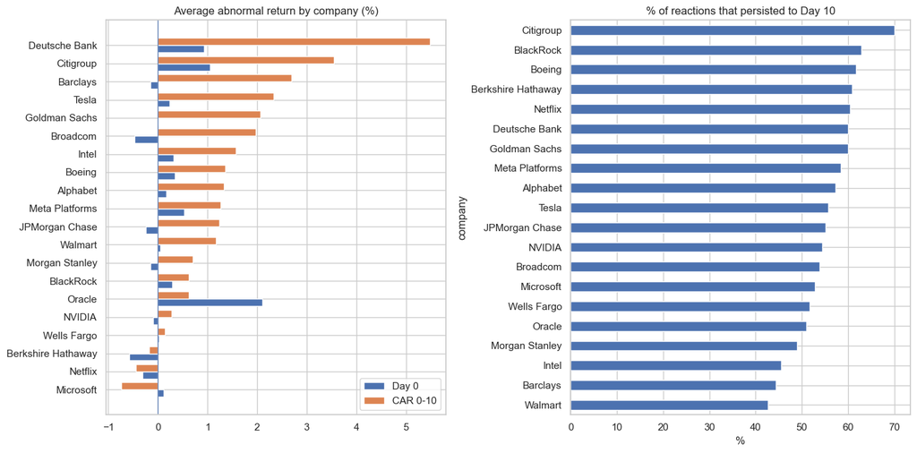

```python
fig, axes = plt.subplots(
    1,
    2,
    figsize=(14, 7)
)

ordered = company_summary.sort_values(
    "avg_CAR_0_10_pct"
)

y = np.arange(
    len(ordered)
)

axes[0].barh(
    y - 0.2,
    ordered["avg_day0_pct"],
    height=0.4,
    label="Day 0"
)

axes[0].barh(
    y + 0.2,
    ordered["avg_CAR_0_10_pct"],
    height=0.4,
    label="CAR 0-10"
)

axes[0].set_yticks(y)

axes[0].set_yticklabels(
    ordered.index
)

axes[0].axvline(
    0,
    linewidth=0.8
)

axes[0].set_title(
    "Average abnormal return by company (%)"
)

axes[0].legend()


company_summary[
    "persisted_pct"
].sort_values().plot.barh(
    ax=axes[1]
)

axes[1].set_title(
    "% of reactions that persisted to Day 10"
)

axes[1].set_xlabel("%")

plt.tight_layout()

plt.savefig(
    OUTPUT_FOLDER /
    "company_analysis.png",
    dpi=150
)

plt.show()
```

```python
# Long-format table:
# one row per event per relative trading day

long_table = events.melt(
    id_vars="event_id",
    value_vars=ar_columns,
    var_name="column",
    value_name="abnormal_return"
)

long_table["relative_day"] = (
    long_table["column"].map(
        dict(
            zip(
                ar_columns,
                range(-1, 11)
            )
        )
    )
)

long_table = (
    long_table
    .drop(columns="column")
    .sort_values(
        [
            "event_id",
            "relative_day"
        ]
    )
)

long_table["car_from_day0"] = (
    long_table[
        "abnormal_return"
    ]
    .where(
        long_table["relative_day"] >= 0,
        0
    )
    .groupby(
        long_table["event_id"]
    )
    .cumsum()
)


events_export = events.copy()

events_export[
    "published_et"
] = events_export[
    "published_et"
].dt.strftime(
    "%Y-%m-%d %H:%M"
)

events_export[
    "reaction_date"
] = events_export[
    "reaction_date"
].dt.strftime(
    "%Y-%m-%d"
)


files = {

    "events_with_reactions.csv":
        events_export,

    "event_window_long.csv":
        long_table,

    "category_summary.csv":
        category_summary.reset_index(),

    "company_summary.csv":
        company_summary.reset_index(),

    "tests_all_events.csv":
        tests_all,

    "tests_one_event_per_day.csv":
        tests_one_per_day,

    "random_day_check.csv":
        check_table.reset_index(),

    "recovery_summary.csv":
        recovery_table.reset_index(),

    "cleaning_steps.csv":
        pd.DataFrame(
            log,
            columns=[
                "step",
                "rows_left"
            ]
        ),
}


for name, table in files.items():

    table.to_csv(
        OUTPUT_FOLDER / name,
        index=False
    )

    print(
        "saved",
        name,
        table.shape
    )
```

```
saved events_with_reactions.csv (1109, 35)
saved event_window_long.csv (13308, 4)
saved category_summary.csv (6, 8)
saved company_summary.csv (20, 9)
saved tests_all_events.csv (9, 7)
saved tests_one_event_per_day.csv (9, 7)
saved random_day_check.csv (3, 5)
saved recovery_summary.csv (2, 5)
saved cleaning_steps.csv (7, 2)
```

# Key Findings

The following section generates the final findings directly from the analysis results.

This avoids manually typing numbers into the conclusion and ensures that the written findings remain connected to the actual dataset.

### Questions answered

1. How large was the average Day 0 reaction?
2. Did the reaction remain significant over the following days?
3. How many reactions persisted until Day 10?
4. How much did large drops recover?
5. How much did large jumps give back?
6. Which event category had the highest and lowest average CAR?
7. How did news-event persistence compare with random trading days?

The results should be interpreted as **observational associations**, not proof that the news event alone caused the stock movement.

```python
row = tests_all.set_index(
    "measure"
)

best_cat = (
    category_summary[
        "avg_CAR_0_10_pct"
    ].idxmax()
)

worst_cat = (
    category_summary[
        "avg_CAR_0_10_pct"
    ].idxmin()
)

drops = recovery_table.loc[
    "Big drop"
]

jumps = recovery_table.loc[
    "Big jump"
]

print(
    f"SAMPLE: {len(events)} events, "
    f"{events['company'].nunique()} companies, "
    f"news from 2025.\n"
)

print(
    f"DAY 0: on average the stock moved "
    f"{row.loc['Day 0', 'average %']:+.2f}% "
    f"versus the market "
    f"(significant: "
    f"{row.loc['Day 0', 'significant at 5%?']})."
)

print(
    f"CAR 0-10: average "
    f"{row.loc['CAR 0-10', 'average %']:+.2f}% "
    f"(Bonferroni-significant: "
    f"{row.loc['CAR 0-10', 'significant at 5%?']})."
)

print(
    f"PERSISTENCE: "
    f"{events['persisted'].mean() * 100:.1f}% "
    f"of reactions were still at least half-size "
    f"on Day 10."
)

print(
    f"PRE-EVENT TIMING: Day -1 abnormal return was "
    f"{events['AR_before'].mean() * 100:+.3f}% "
    f"(p = {p_value:.3f})."
)

print(
    "This suggests that part of the observed reaction "
    "may have occurred before the headline was detected."
)

print()

print(
    f"RECOVERY: after big drops "
    f"(n={int(drops['events'])}), "
    f"the median reversal by Day 10 was "
    f"{drops['median_reversed_pct_day10']:.0f}%."
)

print(
    f"CONTINUATION: after big jumps "
    f"(n={int(jumps['events'])}), "
    f"the median reversal measure was "
    f"{jumps['median_reversed_pct_day10']:.0f}%."
)

print(
    "A negative value means the original jump "
    "continued rather than reversing."
)

print()

print(
    f"CATEGORIES: highest 10-day CAR = "
    f"{best_cat} "
    f"({category_summary.loc[best_cat, 'avg_CAR_0_10_pct']:+.2f}%), "
    f"lowest = "
    f"{worst_cat} "
    f"({category_summary.loc[worst_cat, 'avg_CAR_0_10_pct']:+.2f}%)."
)

print()

print(
    "PLAIN-ENGLISH CONCLUSION:"
)

print(
    "The average immediate reaction was relatively small, "
    "while the cumulative abnormal return over 10 trading "
    "days was positive. However, the significant Day -1 "
    "movement shows that some of the observed reaction may "
    "have occurred before the headline was detected. "
    "The results should therefore be interpreted as "
    "observational associations rather than proof that "
    "the news itself caused the stock movement."
)
```

[output not shown]

# Limitations and Interpretation

This project is designed as a practical data-analysis study, so the results should be interpreted carefully.

### 1. News timestamp limitation

GDELT records when it first observed an article. This may not be the exact time when the underlying news was released.

### 2. Closing-price limitation

Day 0 is based on daily closing prices. If news was published during trading hours, part of the Day 0 movement may have happened before the headline was observed.

### 3. Market benchmark

SPY is used as a simple market benchmark. A more advanced financial model could adjust for each company's beta and other risk factors.

### 4. Event independence

Several events can occur for the same company on the same trading day. Therefore, the analysis also includes tests using one event per company per day.

### 5. Keyword-based categorisation

Event categories are created using keyword rules rather than manually reading every article. Some headlines may therefore be categorised incorrectly.

### 6. Limited sample

The analysis covers 20 large companies and one year of news. Results may not generalise to other companies, sectors or time periods.

# Final Project Summary

This project demonstrates a complete **data-analyst workflow**:

**Extract** → financial news and stock-price data

**Transform** → clean, map, filter, categorise and deduplicate

**EDA** → explore event distributions, stock reactions, categories and companies

**Analyse** → abnormal returns, CAR, persistence and recovery

**Statistical Analysis** → t-tests, Bonferroni adjustment and random-day comparison

**Visualise** → reaction curves, category comparisons and company comparisons

**Load / Report** → Power BI-ready analytical CSV files

### Main skills demonstrated

**Python • Pandas • NumPy • Data Cleaning • Data Transformation • ETL-style Data Preparation • Exploratory Data Analysis (EDA) • Statistical Analysis • Financial Data Analysis • Data Visualization • Power BI**

# Load Analytical Outputs for Power BI

The final stage of the data workflow is to prepare clean analytical outputs for reporting.

The analysis tables are exported as CSV files so they can be loaded directly into Power BI.

### Output tables

- `events_with_reactions.csv`
- `event_window_long.csv`
- `category_summary.csv`
- `company_summary.csv`
- `tests_all_events.csv`
- `tests_one_event_per_day.csv`
- `random_day_check.csv`
- `recovery_summary.csv`
- `cleaning_steps.csv`

The long-format event table is especially useful for Power BI because it contains one row per event and relative trading day.

### Final data workflow

**Raw Data → ETL-style Preparation → EDA → Event Analysis → Statistical Analysis → CSV Outputs → Power BI**

```python
# Load analytical outputs for Power BI

# Long-format event window
long_table = events.melt(
    id_vars="event_id",
    value_vars=ar_columns,
    var_name="column",
    value_name="abnormal_return"
)

long_table["relative_day"] = (
    long_table["column"].map(
        dict(
            zip(
                ar_columns,
                range(-1, 11)
            )
        )
    )
)

long_table = (
    long_table
    .drop(columns="column")
    .sort_values(
        ["event_id", "relative_day"]
    )
)

long_table["car_from_day0"] = (
    long_table["abnormal_return"]
    .where(
        long_table["relative_day"] >= 0,
        0
    )
    .groupby(
        long_table["event_id"]
    )
    .cumsum()
)


# Main event-level export
events_export = events.copy()

events_export["published_et"] = (
    events_export["published_et"]
    .dt.strftime("%Y-%m-%d %H:%M")
)

events_export["reaction_date"] = (
    events_export["reaction_date"]
    .dt.strftime("%Y-%m-%d")
)


files = {
    "events_with_reactions.csv":
        events_export,

    "event_window_long.csv":
        long_table,

    "category_summary.csv":
        category_summary.reset_index(),

    "company_summary.csv":
        company_summary.reset_index(),

    "tests_all_events.csv":
        tests_all,

    "tests_one_event_per_day.csv":
        tests_one_per_day,

    "random_day_check.csv":
        check_table.reset_index(),

    "recovery_summary.csv":
        recovery_table.reset_index(),

    "cleaning_steps.csv":
        pd.DataFrame(
            log,
            columns=[
                "step",
                "rows_left"
            ]
        )
}


for name, table in files.items():

    table.to_csv(
        OUTPUT_FOLDER / name,
        index=False
    )

    print(
        "Saved:",
        name,
        table.shape
    )
```

```
Saved: events_with_reactions.csv (1109, 35)
Saved: event_window_long.csv (13308, 4)
Saved: category_summary.csv (6, 8)
Saved: company_summary.csv (20, 9)
Saved: tests_all_events.csv (9, 7)
Saved: tests_one_event_per_day.csv (9, 7)
Saved: random_day_check.csv (3, 5)
Saved: recovery_summary.csv (2, 5)
Saved: cleaning_steps.csv (7, 2)
```

```python
# ============================================================
# FINAL POWER BI FILE CHECK
# ============================================================

print("POWER BI OUTPUT FILES")
print("=" * 60)

for file in sorted(OUTPUT_FOLDER.glob("*.csv")):
    df_check = pd.read_csv(file)
    print(f"{file.name:<40} {df_check.shape}")
```

```
POWER BI OUTPUT FILES
============================================================
category_summary.csv                     (6, 8)
cleaning_steps.csv                       (7, 2)
company_summary.csv                      (20, 9)
event_window_long.csv                    (13308, 4)
events_with_reactions.csv                (1109, 35)
random_day_check.csv                     (3, 5)
recovery_summary.csv                     (2, 5)
tests_all_events.csv                     (9, 7)
tests_one_event_per_day.csv              (9, 7)
```

```python
from pathlib import Path
from IPython.display import FileLink, display

print("SEARCHING FOR POWER BI CSV FILES...")
print("=" * 60)

file_names = [
    "events_with_reactions.csv",
    "event_window_long.csv",
    "category_summary.csv",
    "company_summary.csv",
    "tests_all_events.csv",
    "tests_one_event_per_day.csv",
    "random_day_check.csv",
    "recovery_summary.csv",
    "cleaning_steps.csv"
]

# Search common locations
search_locations = [
    Path.cwd(),
    Path.home() / "outputs",
    Path.home() / "Desktop",
    Path.home() / "Desktop" / "Stock_Market_Reaction_PowerBI",
]

found_files = {}

for folder in search_locations:
    if folder.exists():
        for name in file_names:
            matches = list(folder.rglob(name))
            for match in matches:
                found_files[name] = match
                break

print()

for name in file_names:
    if name in found_files:
        path = found_files[name]
        print(f"✓ {name}")
        print(f"  Location: {path.resolve()}")
        display(FileLink(str(path)))
    else:
        print(f"✗ {name} - NOT FOUND")

print()
print("Files found:", len(found_files), "of", len(file_names))
```

```
SEARCHING FOR POWER BI CSV FILES...
============================================================

✓ events_with_reactions.csv
  Location: C:\Users\User\outputs\events_with_reactions.csv
```

C:\Users\User\outputs\events_with_reactions.csv

```
✓ event_window_long.csv
  Location: C:\Users\User\outputs\event_window_long.csv
```

C:\Users\User\outputs\event_window_long.csv

```
✓ category_summary.csv
  Location: C:\Users\User\outputs\category_summary.csv
```

C:\Users\User\outputs\category_summary.csv

```
✓ company_summary.csv
  Location: C:\Users\User\outputs\company_summary.csv
```

C:\Users\User\outputs\company_summary.csv

```
✓ tests_all_events.csv
  Location: C:\Users\User\outputs\tests_all_events.csv
```

C:\Users\User\outputs\tests_all_events.csv

```
✓ tests_one_event_per_day.csv
  Location: C:\Users\User\outputs\tests_one_event_per_day.csv
```

C:\Users\User\outputs\tests_one_event_per_day.csv

```
✓ random_day_check.csv
  Location: C:\Users\User\outputs\random_day_check.csv
```

C:\Users\User\outputs\random_day_check.csv

```
✓ recovery_summary.csv
  Location: C:\Users\User\outputs\recovery_summary.csv
```

C:\Users\User\outputs\recovery_summary.csv

```
✓ cleaning_steps.csv
  Location: C:\Users\User\outputs\cleaning_steps.csv
```

C:\Users\User\outputs\cleaning_steps.csv

```
Files found: 9 of 9
```

```python
# ============================================================
# CREATE CLICKABLE POWER BI DOWNLOAD LINKS
# ============================================================

from pathlib import Path
import shutil
from IPython.display import FileLink, display

# Where the CSV files are currently saved
SOURCE_FOLDER = Path(r"C:\Users\User\outputs")

# Create a Power BI folder beside the notebook
DOWNLOAD_FOLDER = Path("PowerBI_Outputs")
DOWNLOAD_FOLDER.mkdir(exist_ok=True)

files = [
    "events_with_reactions.csv",
    "event_window_long.csv",
    "category_summary.csv",
    "company_summary.csv",
    "tests_all_events.csv",
    "tests_one_event_per_day.csv",
    "random_day_check.csv",
    "recovery_summary.csv",
    "cleaning_steps.csv"
]

print("POWER BI DOWNLOAD FILES")
print("=" * 60)

for filename in files:

    source = SOURCE_FOLDER / filename
    destination = DOWNLOAD_FOLDER / filename

    if source.exists():

        # Copy the CSV beside the notebook
        shutil.copy2(source, destination)

        print(f"✓ {filename}")

        # Create clickable Jupyter link
        display(
            FileLink(
                str(destination)
            )
        )

    else:
        print(f"✗ {filename} - NOT FOUND")
```

```
POWER BI DOWNLOAD FILES
============================================================
✓ events_with_reactions.csv
```

PowerBI_Outputs\events_with_reactions.csv

```
✓ event_window_long.csv
```

PowerBI_Outputs\event_window_long.csv

```
✓ category_summary.csv
```

PowerBI_Outputs\category_summary.csv

```
✓ company_summary.csv
```

PowerBI_Outputs\company_summary.csv

```
✓ tests_all_events.csv
```

PowerBI_Outputs\tests_all_events.csv

```
✓ tests_one_event_per_day.csv
```

PowerBI_Outputs\tests_one_event_per_day.csv

```
✓ random_day_check.csv
```

PowerBI_Outputs\random_day_check.csv

```
✓ recovery_summary.csv
```

PowerBI_Outputs\recovery_summary.csv

```
✓ cleaning_steps.csv
```

PowerBI_Outputs\cleaning_steps.csv

```python
# ============================================================
# CONVERT EXISTING CSV OUTPUTS TO REAL EXCEL FILES
# ============================================================

from pathlib import Path
from IPython.display import FileLink, display
import pandas as pd

# Existing CSV files
SOURCE_FOLDER = Path(r"C:\Users\User\outputs")

# Final Excel files will be placed beside the notebook
POWERBI_FOLDER = Path("PowerBI_Final")
POWERBI_FOLDER.mkdir(exist_ok=True)

files = [
    "events_with_reactions.csv",
    "event_window_long.csv",
    "category_summary.csv",
    "company_summary.csv",
    "tests_all_events.csv",
    "tests_one_event_per_day.csv",
    "random_day_check.csv",
    "recovery_summary.csv",
    "cleaning_steps.csv"
]

print("CREATING POWER BI EXCEL FILES")
print("=" * 60)

for csv_name in files:

    csv_path = SOURCE_FOLDER / csv_name

    if not csv_path.exists():
        print(f"X {csv_name} - NOT FOUND")
        continue

    # Read the existing CSV
    df = pd.read_csv(csv_path)

    # Change .csv to .xlsx
    xlsx_name = csv_name.replace(".csv", ".xlsx")
    xlsx_path = POWERBI_FOLDER / xlsx_name

    # Create a genuine Excel workbook
    df.to_excel(
        xlsx_path,
        sheet_name="Data",
        index=False,
        engine="openpyxl"
    )

    print(f"✓ {xlsx_name}  {df.shape}")

    # Clickable Jupyter download link
    display(FileLink(str(xlsx_path)))

print()
print("DONE")
print("Excel folder:", POWERBI_FOLDER.resolve())
```

```
CREATING POWER BI EXCEL FILES
============================================================
✓ events_with_reactions.xlsx  (1109, 35)
```

PowerBI_Final\events_with_reactions.xlsx

```
✓ event_window_long.xlsx  (13308, 4)
```

PowerBI_Final\event_window_long.xlsx

```
✓ category_summary.xlsx  (6, 8)
```

PowerBI_Final\category_summary.xlsx

```
✓ company_summary.xlsx  (20, 9)
```

PowerBI_Final\company_summary.xlsx

```
✓ tests_all_events.xlsx  (9, 7)
```

PowerBI_Final\tests_all_events.xlsx

```
✓ tests_one_event_per_day.xlsx  (9, 7)
```

PowerBI_Final\tests_one_event_per_day.xlsx

```
✓ random_day_check.xlsx  (3, 5)
```

PowerBI_Final\random_day_check.xlsx

```
✓ recovery_summary.xlsx  (2, 5)
```

PowerBI_Final\recovery_summary.xlsx

```
✓ cleaning_steps.xlsx  (7, 2)
```

PowerBI_Final\cleaning_steps.xlsx

```
DONE
Excel folder: C:\Users\User\PowerBI_Final
```